# Ecological Modelling

RJB

2026-03-13

## Purpose

This notebook is now the reporting layer for the current `gpath` modelling workflow. It is not intended to recreate the full analysis from scratch. Instead it:

- documents the current modelling path,
- states the upstream scripts/commands that generate required artefacts where known,
- loads saved results from the current workflow,
- presents model selection, diagnostics, transfer results, and parameter-transfer summaries.

Where an upstream command is not known exactly from the repo history, that is stated explicitly.

Oracle NUTS note: this chunk now treats the full-data oracle job definition in `config/jobs/gpath_full_oracle_assessment.json` as the source of truth for which model IDs should be checked and where their standard per-model NUTS output directories should live. The deployment path for that job is: materialize per-task configs with `scripts/prepare_jobs.R`, submit the resulting manifest with `slurm/submit_gpath_full_oracle_job.sh`, dispatch array tasks through `slurm/jobs/gpath_full_oracle_array.sh`, and execute each task via the R entrypoint `scripts/run_job.R`, which sources `R/job_config_utils.R` and then calls the generic sampler in `R/nuts_utils.R`.

```
## Processed 12/12 model ids from config/jobs/gpath_full_oracle_assessment.json
## Output root: data/gpath_full_oracle_assessment
## Thresholds: rhat > 1.01, ess < 400
```

```
##        model_id selected_run_tag n_available_oracle_run_tags n_draws
##  1R_1P_0W_C0_M1          chain01                           4    1000
##  1R_1P_1W_C0_M0          chain01                           4    1000
##  1R_1P_1W_C0_M1          chain01                           4    1000
##  2R_1P_0W_C0_M1          chain01                           4    1000
##  2R_1P_1W_C0_M0          chain01                           4    1000
##  2R_1P_1W_C0_M1          chain01                           4    1000
##  2R_2P_0W_C0_M1          chain01                           4    1000
##  2R_2P_0W_C1_M0          chain01                           4    1000
##  2R_2P_1W_C0_M0          chain01                           4    1000
##  2R_2P_1W_C0_M1          chain01                           4    1000
##  2R_2P_1W_C1_M0          chain01                           4    1000
##  2R_2P_1W_C1_M1          chain01                           4    1000
##  n_parameters n_chains n_bad_rhat n_bad_ess_bulk n_bad_ess_tail max_rhat
##           235        1          0              0              0 1.009251
##           241        1          0              0              0 1.007830
##           241        1          2              0              0 1.014519
##           253        1          1              1              0 1.012138
##           265        1          0             23              4 1.009700
##           265        1          3             22             22 1.012411
##           265        1          0              1              1 1.006708
##           265        1          0              0              1 1.007599
##           277        1          0              6              6 1.008076
##           277        1          3              1              2 1.012725
##           277        1          0              2              4 1.009385
##           277        1         10             36             18 1.019227
##  min_ess_bulk min_ess_tail
##      417.8843    408.35977
##      425.0227    467.68977
##      400.0247    406.54510
##      373.1421    513.01163
##      186.2111    362.57966
##      160.0551     56.66231
##      397.1353    294.73930
##      458.1199    309.45292
##      295.2769    268.24005
##      343.7566    291.62940
##      326.6550    254.82417
##       77.8850     31.07673
```

```
##        model_id n_lines n_draws_sampled n_surface_rows
##  1R_1P_0W_C0_M1       5              20           3125
##  1R_1P_1W_C0_M0       5              20           3125
##  1R_1P_1W_C0_M1       5              20           3125
##  2R_1P_0W_C0_M1       5              20           3125
##  2R_1P_1W_C0_M0       5              20           3125
##  2R_1P_1W_C0_M1       5              20           3125
##  2R_2P_0W_C0_M1       5              20           3125
##  2R_2P_0W_C1_M0       5              20           3125
##  2R_2P_1W_C0_M0       5              20           3125
##  2R_2P_1W_C0_M1       5              20           3125
##  2R_2P_1W_C1_M0       5              20           3125
##  2R_2P_1W_C1_M1       5              20           3125
```

## Model Selection

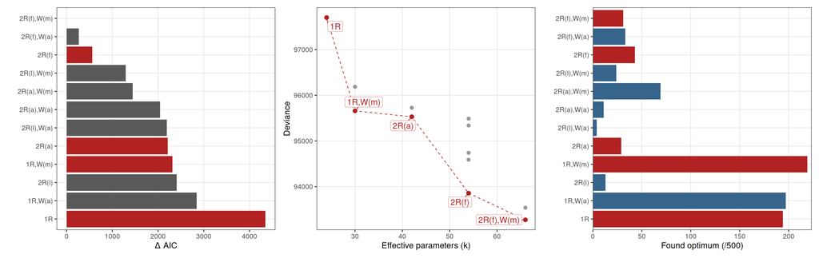

```
##  line_id    line_name
##        1       MCF10A
##        2   MDA-MB-231
##        3       SNU668
##        4 SUM-159-chem
##        5 SUM-159-fuse
##                                                                    output_path
##  dev-figs/model_analysis/pareto_global_fit_overlays/line_01_pareto_overlay.png
##  dev-figs/model_analysis/pareto_global_fit_overlays/line_02_pareto_overlay.png
##  dev-figs/model_analysis/pareto_global_fit_overlays/line_03_pareto_overlay.png
##  dev-figs/model_analysis/pareto_global_fit_overlays/line_04_pareto_overlay.png
##  dev-figs/model_analysis/pareto_global_fit_overlays/line_05_pareto_overlay.png
##  status
##  cached
##  cached
##  cached
##  cached
##  cached
```

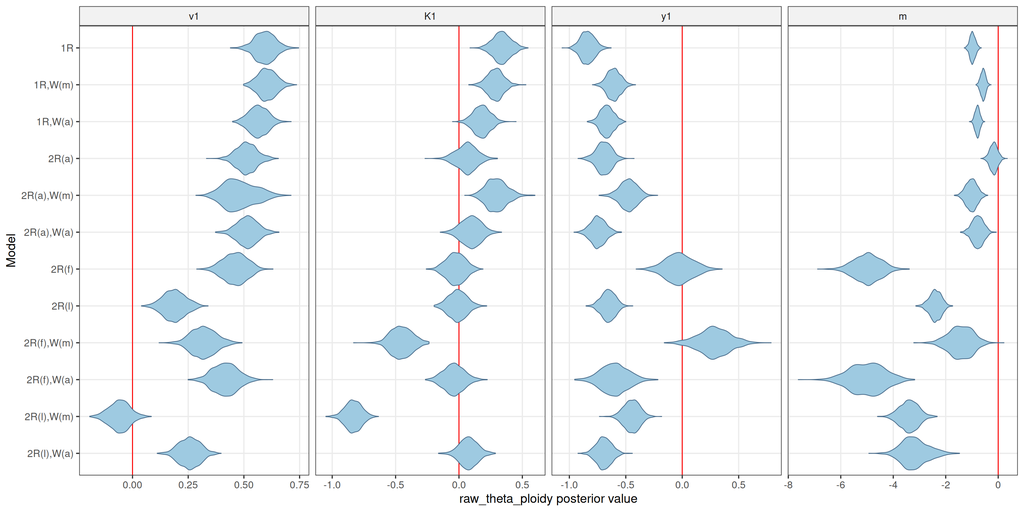

VERY IMPORTANT: Sandy said we should think harder about interpreting results in terms of differences between cell lines. The `nuts-line-parameter-posteriors-demo` block below is important for that, because it exposes the line-specific posterior parameter structure directly rather than only the shared ploidy-effect coefficients. A plausible next step is to operationalize this in holdout tests by asking whether ploidy-effect transfer works better between cell lines with more similar line-specific parameter sets.

```
## 1R
## ae[1], ah[1], Y_R[1], A_mat[1,1], m
##
## 1R,W(m)
## ae[1], ah[1], Y_R[1], A_mat[1,1], K_mat[1,1], m
##
## 2R(a)
## ae[1], ae[2], ah[1], ah[2], Y_R[1], Y_R[2], A_mat[1,1], A_mat[1,2], m
##
## 2R(f)
## ae[1], ae[2], ah[1], ah[2], Y_R[1], Y_R[2], A_mat[1,1], A_mat[1,2], A_mat[2,1], A_mat[2,2], m
##
## 2R(f),W(m)
## ae[1], ae[2], ah[1], ah[2], Y_R[1], Y_R[2], A_mat[1,1], A_mat[1,2], A_mat[2,1], A_mat[2,2], K_mat[1,1], K_mat[1,2], m
```

```
## Model: 2R_2P_1W_C0_M0 | alias: 2R(f),W(m) | draw_row: 1 | line_id: 1 | ploidy_metric: 0
##
## Output of reconstruct_parms():
## $R
## [1] 2
##
## $P
## [1] 2
##
## $W
## [1] 1
##
## $ae
## raw_theta_line[1,1] raw_theta_line[2,1]
##        1.036969e-05        2.729544e-06
##
## $ah
## raw_theta_line[3,1] raw_theta_line[4,1]
##           0.7627523           0.5652758
##
## $Y_R
## raw_theta_line[5,1] raw_theta_line[6,1]
##           222111.68            59290.62
##
## $A_mat
##            [,1]      [,2]
## [1,] 0.97358545 0.5646915
## [2,] 0.02641455 0.4353085
##
## $K_mat
##          [,1]      [,2]
## [1,] 1.738408 0.1840873
##
## $m
## raw_theta_line[11,1]
##           0.01131956
##
## $waste_mech
## [1] 0
##
##
## Output of flatten_gpath_reconstructed_parms():
##             R             P             W         ae[1]         ae[2]
##  2.000000e+00  2.000000e+00  1.000000e+00  1.036969e-05  2.729544e-06
##         ah[1]         ah[2]        Y_R[1]        Y_R[2]    A_mat[1,1]
##  7.627523e-01  5.652758e-01  2.221117e+05  5.929062e+04  9.735854e-01
##    A_mat[1,2]    A_mat[2,1]    A_mat[2,2]    K_mat[1,1]    K_mat[1,2]
##  5.646915e-01  2.641455e-02  4.353085e-01  1.738408e+00  1.840873e-01
##             m waste_mech[1]
##  1.131956e-02  0.000000e+00
```

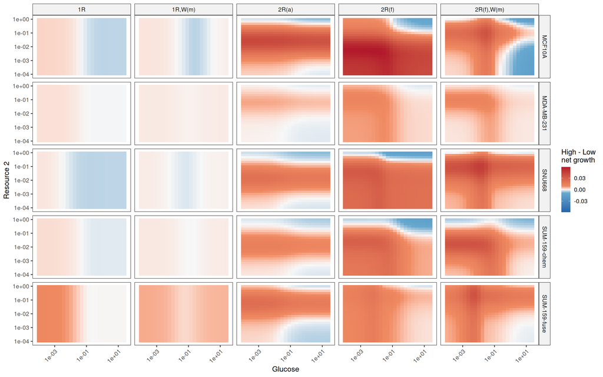

[figure not shown]

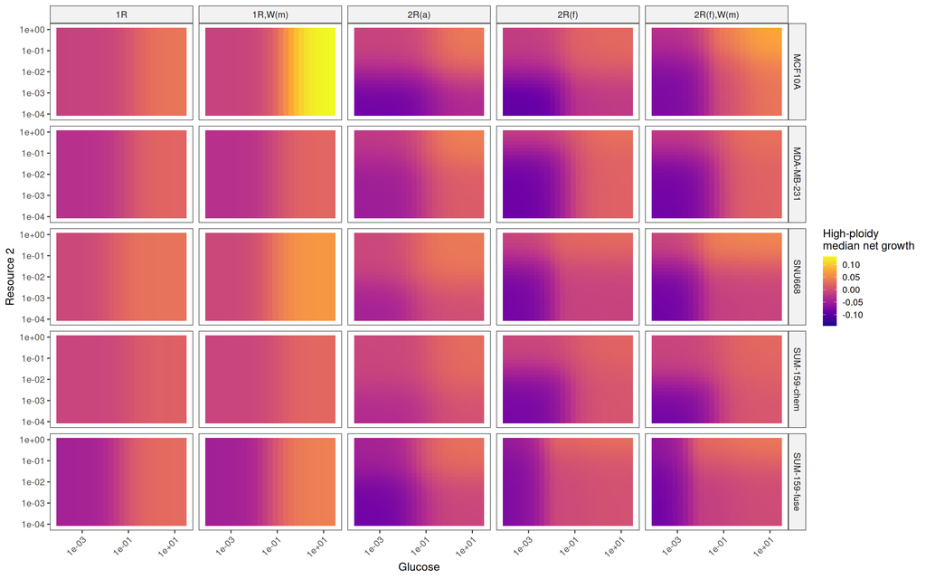

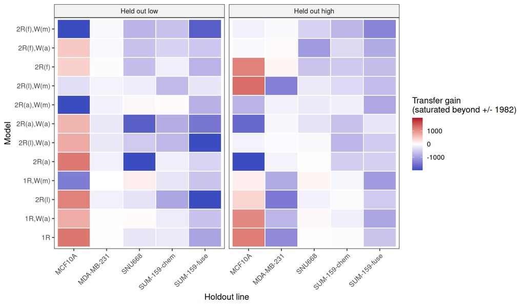

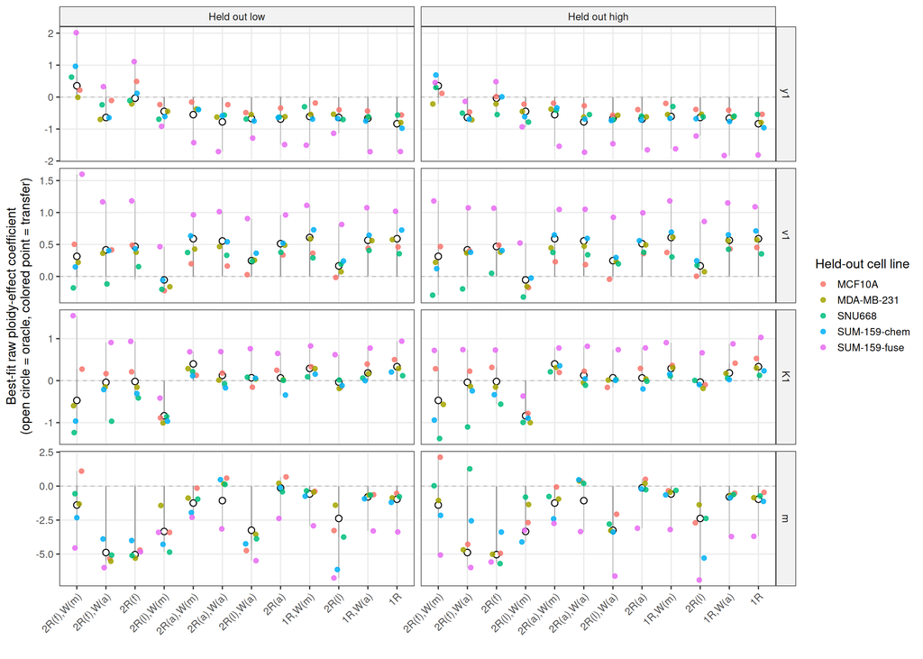

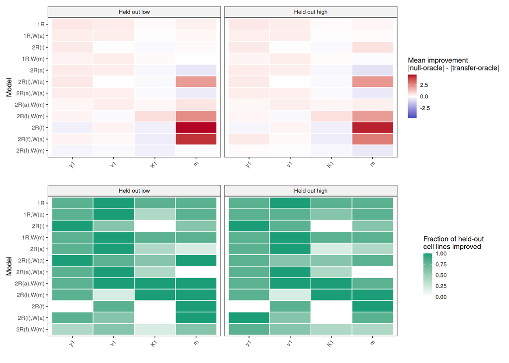